# Tercera sesión de laboratorio

01/03/2015

## Tratamiento 1

- Dos empresas sirven el mercado de un producto homogéneo.
- Cada periodo se divide en dos etapas:
  - La empresa líder decide cuántas unidades va a producir.
  - La empresa seguidora decide su producción *conociendo la decisión de la líder*.
- El coste de producción unitario de la empresa líder es de \(200\ €\), mientras que el de la empresa seguidora es \(290\ €\).
- La demanda determina el precio al que se venden todas las unidades.

## Costes

- El coste unitario es independiente de la producción: \[ CMe_1(q_1) = 200; \qquad CMe_2(q_2) = 290 \]
- Los costes de cada una de las empresas son: \[ C_1(q_1) = 200 q_1; \qquad C_2(q_2) = 290 q_2 \]
- El coste marginal coincide con el coste unitario: \[ CMg_1(q_1) = \frac{\mathrm{d}\; C_1(q_1)}{\mathrm{d}\; q_1} = 200; \quad CMg_2(q_2) = 290 \]

## Demanda

- La curva inversa de demanda del mercado es: \[ P = 500 - \frac{1}{2} Q \]
- La producción total, \(Q\), es la suma de las producciones de cada empresa: \[ Q = q_1 + q_2 \]
- Por tanto: \[ P = 500 - \frac{1}{2} (q_1 + q_2) \]

## Ingresos

- Los ingresos de la empresa \(2\) son: \[ I_2(q_2) = P q_2 \]
- Sustituyendo la curva de demanda en la expresión anterior: \[ I_2(q_2) = \Big(500 - \frac{q_1}{2} - \frac{q_2}{2}\Big) q_2 \]
- Ingreso marginal de la empresa 2: \[ IMg_2(q_2) = \frac{\mathrm{d}\; I_2(q_2)}{\mathrm{d}\; q_2} = 500 - \frac{q_1}{2} - q_2 \]

## Producción del seguidor

- Condición de primer orden para la maximización del beneficio: \[ IMg_2(q_2^*) = CMg_2(q_2^*) \]
- En nuestro caso: \[ 500 - \frac{q_1}{2} - q_2^* = 290 \]
- Función de reacción del seguidor: \[ q_2^* = 210 - \frac{q_1}{2} \]

## Ingresos del líder

- Sustituimos la reacción del seguidor en la curva de demanda: \[ P = 500 -\frac{1}{2}(q_1 + 210 - \frac{1}{2} q_1) = 395 -\frac{1}{4} q_1 \]
- Los ingresos del líder son: \[ I_1(q_1) = P q_1 = 395 q_1 - \frac{1}{4} q_1^2 \]
- Ingreso marginal de la empresa 1: \[ IMg_1(q_1) = \frac{\mathrm{d}\; I_1(q_1)}{\mathrm{d}\; q_1} = 395 - \frac{1}{2} q_1 \]

## Producción del líder

- Condición de primer orden para la maximización del beneficio: \[ IMg_1(q_1^*) = CMg_1(q_1^*) \]
- En nuestro caso: \[ 395 - \frac{q_1^*}{2} = 200 \]
- Por tanto: \[ q_1^* = 390\ \text{u.} \]

## Equilibrio: producción

- El líder produce \(q^*_1 = 390\) unidades.
- La reacción óptima del seguidor es: \[ q^*_2 = 210 - q^*_1 /2 = 15\ \text{unidades.} \]
- La producción de mercado es \[ Q^* = q^*_1 + q^*_2 = 390 + 15 = 405\ \text{unidades.} \]

## Equilibrio: precios y beneficios

- La demanda determina el precio: \[ P^* = 500 - Q^*/2 = 500 - 405/2 = 297{,}5 \ \text{€/u.} \]
- El beneficio del líder es \[ \pi_1 = (P^* - CMe) q^*_1 = (297{,}5 - 200) \times 390 = 38025\ \text{€}. \]
- El beneficio del líder es \[ \pi_2 = (P^* - CMe) q^*_2 = (297{,}5 - 290) \times 15 = 112{,}5\ \text{€}. \]

## Resultados del laboratorio

- Sesiones del 23 de febrero (grupo F) y 24 de febrero (grupo A) de 2015.
- Cada tratamiento estaba compuesto por 7 periodos.
- Número de sujetos: 72.

## Estadísticos descriptivos

### Producción del líder

| Period | Mean | SD | Min | 25% | Median | 75% | Max |
| --- | --- | --- | --- | --- | --- | --- | --- |
| 1 | 307.2 | 47.9 | 200 | 295.0 | 300.0 | 350.0 | 450 |
| 2 | 303.4 | 57.7 | 150 | 278.8 | 300.0 | 350.0 | 400 |
| 3 | 276.9 | 80.1 | 0 | 249.8 | 287.5 | 300.0 | 450 |
| 4 | 260.8 | 72.6 | 0 | 203.8 | 265.0 | 316.2 | 400 |
| 5 | 251.3 | 92.3 | 0 | 208.8 | 252.5 | 300.0 | 450 |
| 6 | 277.6 | 70.0 | 160 | 239.2 | 277.5 | 301.2 | 500 |
| 7 | 266.1 | 94.6 | 0 | 220.0 | 290.0 | 312.8 | 450 |

## Estadísticos descriptivos

### Producción del seguidor

| Period | Mean | SD | Min | 25% | Median | 75% | Max |
| --- | --- | --- | --- | --- | --- | --- | --- |
| 1 | 216.9 | 82.5 | 50 | 157.5 | 210.0 | 285.0 | 375 |
| 2 | 216.4 | 122.2 | 15 | 118.8 | 200.0 | 300.0 | 500 |
| 3 | 155.8 | 88.7 | 0 | 100.0 | 122.5 | 200.0 | 350 |
| 4 | 153.3 | 117.1 | 0 | 65.0 | 117.5 | 240.0 | 400 |
| 5 | 164.0 | 114.1 | 0 | 87.5 | 117.5 | 243.8 | 500 |
| 6 | 166.7 | 127.8 | 0 | 78.0 | 122.5 | 220.0 | 500 |
| 7 | 132.5 | 108.5 | 0 | 58.8 | 100.0 | 180.0 | 500 |

## Distribución de la producción

### Empresa líder

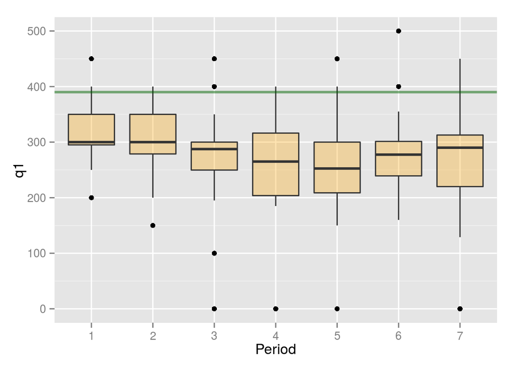

## Distribución de la producción

### Empresa seguidora

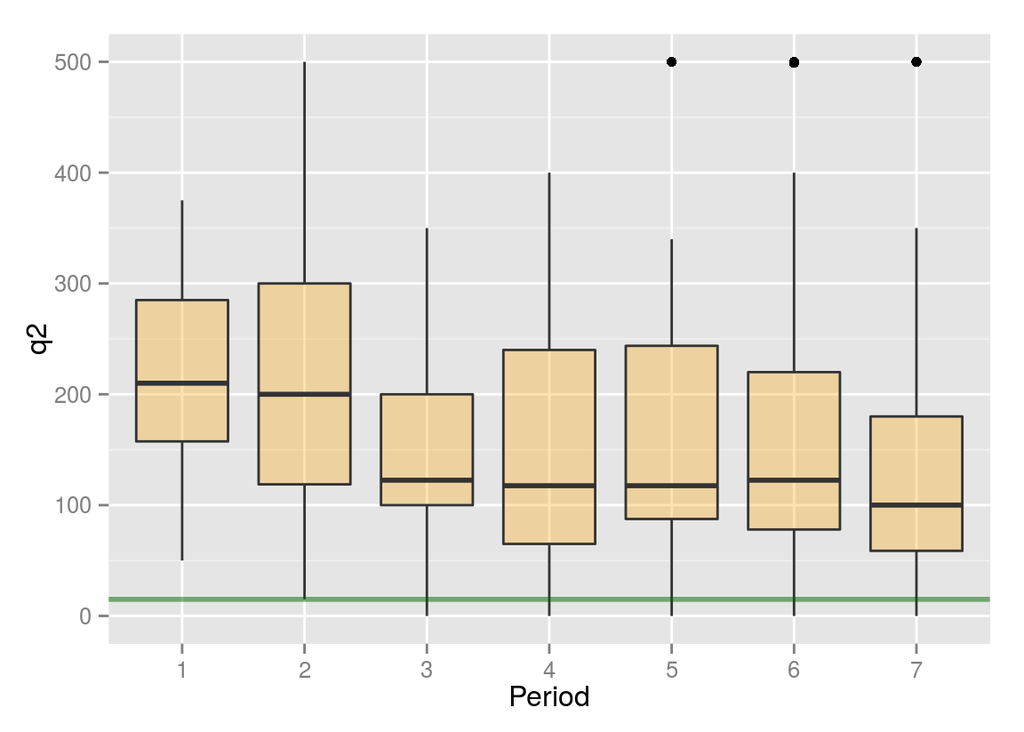

## Comparación de las cantidades

### Diferencia de las producciones del líder y del seguidor

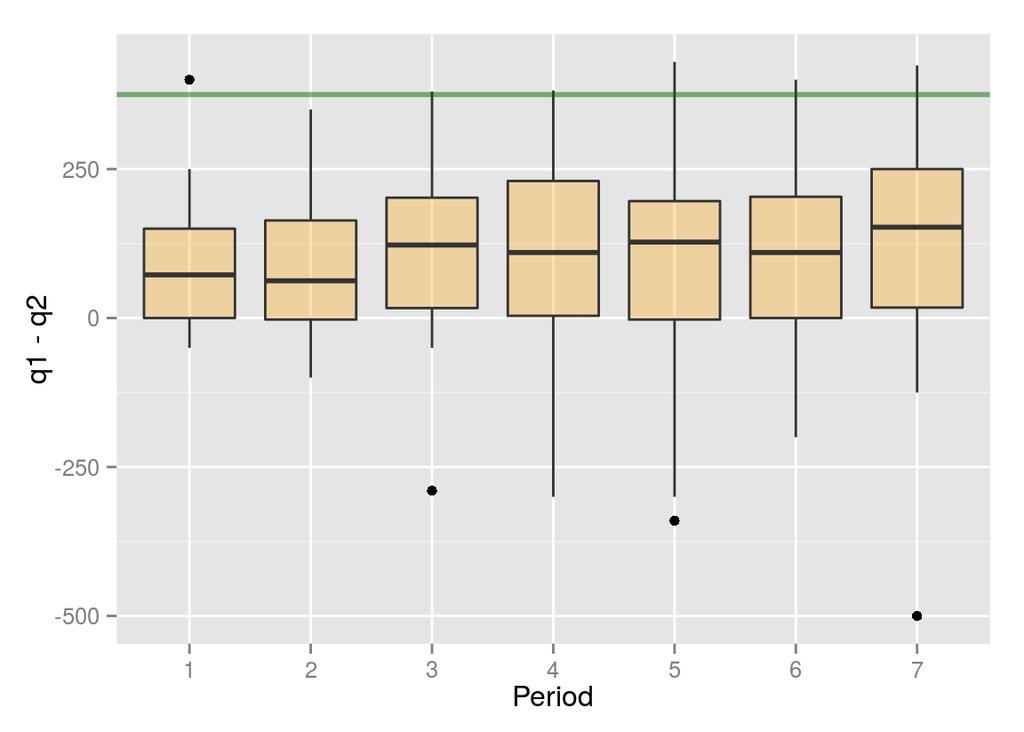

## Comparación de las cantidades

### Producciones del líder y del seguidor

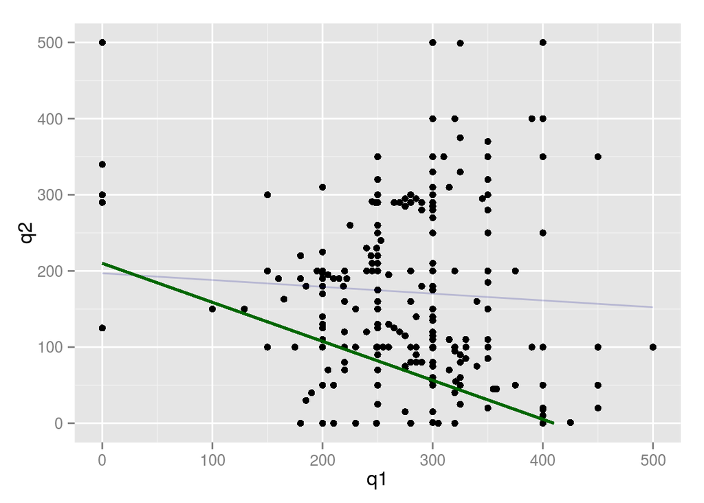

## Comparación de las cantidades

### Correlación de las producciones por período

| Period | rho |
| --- | --- |
| 1 | -0.11 |
| 2 | 0.34 |
| 3 | -0.26 |
| 4 | -0.02 |
| 5 | -0.27 |
| 6 | 0.04 |
| 7 | -0.46 |

## Tratamiento 2

- Dos empresas sirven el mercado de un producto homogéneo.
- El coste unitario de la empresa 1 es de \(200\ €\) mientras que el de la empresa 2 es de \(290\ €\).
- Cada periodo las empresas deciden simultáneamente cuántas unidades va a producir.
- La demanda determina el precio al que se venden todas las unidades.

## La elección del nivel de producción

- Funciones de reacción: \[ \begin{gather*} q_1^* = 300 - \frac{q_2}{2} \\ q_2^* = 210 - \frac{q_1}{2} \end{gather*} \]
- La primera ecuación expresa la producción que maximiza los beneficios de la empresa 1 *si la empresa 2 produce \(q_2\)*.
- La segunda ecuación expresa la producción que maximiza los beneficios de la empresa 2 *si la empresa 1 produce \(q_1\)*.

## Equilibrio de Nash

- En equilibrio la producción de cada una de las empresas es la mejor respuesta a las decisiones de producción de sus rivales. \[ \begin{gather*} q_1^* = 300 - \frac{q^*_2}{2} \\ q_2^* = 210 - \frac{q^*_1}{2} \end{gather*} \]
- En equilibrio \(q^*_1 = 260\) y \(q^*_2 = 80\) unidades.
- El precio de equilibrio es \(P^* = 500 - 340/2 = 330\) €/u.
- Los beneficios son \(\pi^*_1 = 33800\) y \(\pi^*_2 = 3200\) €.

## Estadísticos descriptivos

### Producción de la empresa con costes bajos

| Period | Mean | SD | Min | 25% | Median | 75% | Max |
| --- | --- | --- | --- | --- | --- | --- | --- |
| 1 | 280.7 | 68.8 | 100 | 250.0 | 300.0 | 315.0 | 400 |
| 2 | 288.8 | 92.8 | 0 | 250.0 | 295.0 | 350.0 | 500 |
| 3 | 265.7 | 84.3 | 65 | 217.5 | 282.5 | 312.2 | 450 |
| 4 | 256.2 | 100.8 | 0 | 200.0 | 277.5 | 300.0 | 500 |
| 5 | 274.4 | 84.2 | 95 | 200.0 | 292.5 | 312.5 | 490 |
| 6 | 274.2 | 96.1 | 0 | 200.0 | 286.0 | 342.5 | 500 |
| 7 | 271.2 | 88.7 | 0 | 215.0 | 296.0 | 316.2 | 460 |

## Estadísticos descriptivos

### Producción de la empresa con costes altos

| Period | Mean | SD | Min | 25% | Median | 75% | Max |
| --- | --- | --- | --- | --- | --- | --- | --- |
| 1 | 231.2 | 119.2 | 30 | 148.8 | 237.5 | 300.0 | 500 |
| 2 | 177.4 | 94.7 | 30 | 100.0 | 150.0 | 250.0 | 400 |
| 3 | 176.7 | 117.7 | 15 | 97.5 | 140.0 | 291.2 | 400 |
| 4 | 151.1 | 95.4 | 15 | 87.5 | 127.5 | 200.0 | 370 |
| 5 | 126.5 | 97.4 | 0 | 50.0 | 95.0 | 186.2 | 329 |
| 6 | 144.4 | 126.0 | 20 | 66.2 | 100.0 | 167.5 | 500 |
| 7 | 114.1 | 78.1 | 0 | 57.5 | 100.0 | 150.0 | 325 |

## Distribución de la producción

### Empresa con costes bajos

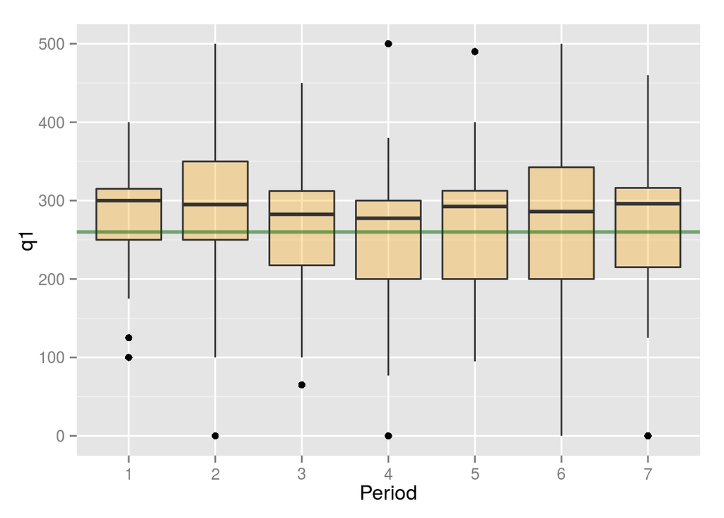

## Distribución de la producción

### Empresa con costes altos

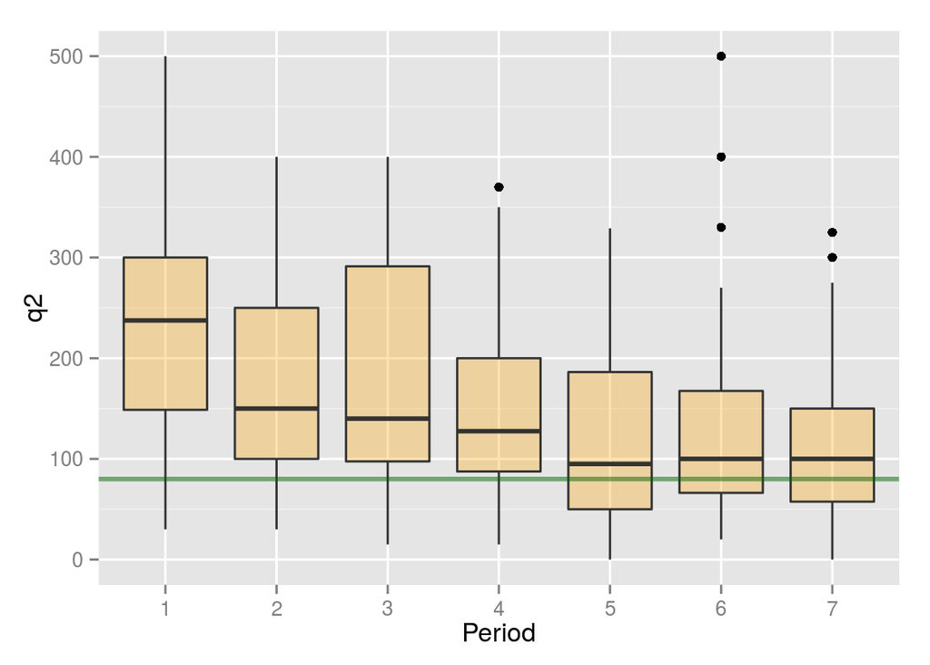

## Comparación de las cantidades

### Diferencia de las producciones de las dos empresas

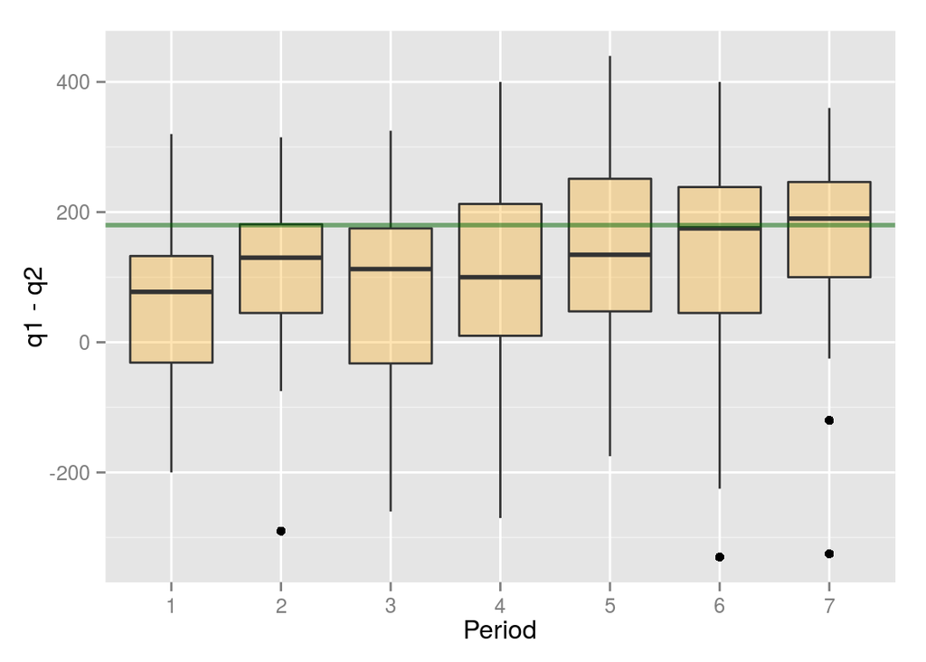